# Homework 2: Data Frames Apply and Plotting

Statistical Computing, 36-350

Week of Monday July 9, 2018

Name: Gabriel Krotkov Andrew ID: gkrotkov Collaborated with: Steve Kim

On this homework, you can collaborate with your classmates, but you must identify their names above, and you must submit **your own** homework as an knitted HTML file on Canvas, by Monday 10pm, next week (July 16).

# States data set

Below we construct a data frame, of 50 states x 10 variables. The first 8 variables are numeric and the last 2 are factors. The numeric variables here come from the built-in `state.x77` matrix, which records various demographic factors on 50 US states, measured in the 1970s. You can learn more about this state data set by typing `?state.x77` into your R console.

```r
state.df <- data.frame(state.x77, Region=state.region, Division=state.division)
```

# Basic data frame manipulations

- **1a.** Add a column to `state.df`, containing the state abbreviations that are stored in the built-in vector `state.abb`. Name this column `Abbr`. You can do this in (at least) two ways: by using a call to `data.frame()`, or by directly defining `state.df$Abbr`. Display the first 3 rows and all 11 columns of the new `state.df`.

```r
state.df$Abbr <- state.abb

head(state.df, 3)
```

```
##         Population Income Illiteracy Life.Exp Murder HS.Grad Frost   Area
## Alabama       3615   3624        2.1    69.05   15.1    41.3    20  50708
## Alaska         365   6315        1.5    69.31   11.3    66.7   152 566432
## Arizona       2212   4530        1.8    70.55    7.8    58.1    15 113417
##         Region           Division Abbr
## Alabama  South East South Central   AL
## Alaska    West            Pacific   AK
## Arizona   West           Mountain   AZ
```

- **1b.** Remove the `Region` column from `state.df`. You can do this in (at least) two ways: by using negative indexing, or by directly setting `state.df$Region` to be `NULL`. Display the first 3 rows and all 10 columns of `state.df`.

```r
state.df$Region <- NULL

head(state.df, 3)
```

```
##         Population Income Illiteracy Life.Exp Murder HS.Grad Frost   Area
## Alabama       3615   3624        2.1    69.05   15.1    41.3    20  50708
## Alaska         365   6315        1.5    69.31   11.3    66.7   152 566432
## Arizona       2212   4530        1.8    70.55    7.8    58.1    15 113417
##                   Division Abbr
## Alabama East South Central   AL
## Alaska             Pacific   AK
## Arizona           Mountain   AZ
```

- **1c.** Add two columns to `state.df`, containing the x and y coordinates (longitude and latitude, respectively) of the center of the states, that are stored in the (existing) list `state.center`. Hint: take a look at this list in the console, to see what its elements are named. Name these two columns `Center.x` and `Center.y`. Display the first 3 rows and all 12 columns of `state.df`.

```r
state.df$Center.x <- state.center$x
state.df$Center.y <- state.center$y

head(state.df, 3)
```

```
##         Population Income Illiteracy Life.Exp Murder HS.Grad Frost   Area
## Alabama       3615   3624        2.1    69.05   15.1    41.3    20  50708
## Alaska         365   6315        1.5    69.31   11.3    66.7   152 566432
## Arizona       2212   4530        1.8    70.55    7.8    58.1    15 113417
##                   Division Abbr  Center.x Center.y
## Alabama East South Central   AL  -86.7509  32.5901
## Alaska             Pacific   AK -127.2500  49.2500
## Arizona           Mountain   AZ -111.6250  34.2192
```

- **1d.** Make a new data.frame which contains only those states whose longitude is less than -100. Do this in two different ways and check that they are equal to each other, using an appropriate function call.

```r
state.df2 <- state.df[state.df$Center.x < -100,]
state.df3 <- subset(state.df,
                    subset = Center.x < -100)

all.equal(state.df2, state.df3)
```

```
## [1] TRUE
```

# Prostate cancer data set

Let’s return to the prostate cancer data set that we looked at in the lab/homework from Week 2 (taken from the book [The Elements of Statistical Learning](http://statweb.stanford.edu/~hastie/ElemStatLearn/)). Below we read in a data frame of 97 men x 9 variables. You can remind yourself about what’s been measured by looking back at the lab/homework (or by visiting the URL linked above in your web browser, clicking on “Data” on the left-hand menu, and clicking “Info” under “Prostate”).

```r
pros.dat <-
  read.table("https://raw.githubusercontent.com/linnylin92/36-350_public/master/dat/pros.dat")
```

# Practice with the apply family

- **2a.** Using `sapply()`, calculate the mean of each variable. Also, calculate the standard deviation of each variable. Each should require just one line of code. Display your results.

```r
sapply(pros.dat, FUN = mean)
```

```
##     lcavol    lweight        age       lbph        svi        lcp
##  1.3500096  3.6289427 63.8659794  0.1003556  0.2164948 -0.1793656
##    gleason      pgg45       lpsa
##  6.7525773 24.3814433  2.4783869
```

```r
sapply(pros.dat, FUN = sd)
```

```
##     lcavol    lweight        age       lbph        svi        lcp
##  1.1786249  0.4284112  7.4451171  1.4508066  0.4139949  1.3982496
##    gleason      pgg45       lpsa
##  0.7221341 28.2040346  1.1543291
```

- **2b.** Now, use `lapply()` to perform t-tests for each variable in the data set, between SVI and non-SVI groups. To be precise, you will perform a t-test for each variable excluding the SVI variable itself. For convenience, we’ve defined a function `t.test.by.ind()` below, which takes a numeric variable `x`, and then an indicator variable `ind` (of 0s and 1s) that defines the groups. Run this function on the columns of `pros.dat`, and save the result as `tests`. What kind of data structure is `tests`? Print it to the console.

```r
t.test.by.ind <- function(x, ind) {
  stopifnot(all(ind %in% c(0, 1)))
  return(t.test(x[ind == 0], x[ind == 1]))
}

tests <- lapply(pros.dat[-5],
                FUN = t.test.by.ind,
                ind = pros.dat["svi"]==1)

typeof(tests)
```

```
## [1] "list"
```

- **Challenge.** Using an appropriate apply function again, extract the p-values from the `tests` object you created in the last question, with just a single line of code. Hint: run the command `"[["(pros.dat, "lcavol")` in your console—what does this do?

# Rio Olympics data set

It’s Winter Olympics time! To get into the Olympics spirit, we’re going to examine data from the 2016 Summer Olympics in Rio de Janeiro, taken from https://github.com/flother/rio2016 (itself put together by scraping the official Summer Olympics website for information about the athletes). Below we read in the data and store it as `rio`.

```r
rio <- read.csv("https://raw.githubusercontent.com/linnylin92/36-350_public/master/dat/rio.csv", stringsAsFactors = FALSE)
```

# More practice with data frames and apply

- **3a.** Call `summary()` on `rio` and display the result. Is there any missing data?

```r
summary(rio)
```

```
##        id                name           nationality
##  Min.   :    18347   Length:11538       Length:11538
##  1st Qu.:245099667   Class :character   Class :character
##  Median :500201062   Mode  :character   Mode  :character
##  Mean   :499988509
##  3rd Qu.:753987424
##  Max.   :999987786
##
##      sex            date_of_birth          height          weight
##  Length:11538       Length:11538       Min.   :1.210   Min.   : 31.00
##  Class :character   Class :character   1st Qu.:1.690   1st Qu.: 60.00
##  Mode  :character   Mode  :character   Median :1.760   Median : 70.00
##                                        Mean   :1.766   Mean   : 72.07
##                                        3rd Qu.:1.840   3rd Qu.: 81.00
##                                        Max.   :2.210   Max.   :170.00
##                                        NA's   :330     NA's   :659
##     sport                gold             silver            bronze
##  Length:11538       Min.   :0.00000   Min.   :0.00000   Min.   :0.00000
##  Class :character   1st Qu.:0.00000   1st Qu.:0.00000   1st Qu.:0.00000
##  Mode  :character   Median :0.00000   Median :0.00000   Median :0.00000
##                     Mean   :0.05772   Mean   :0.05677   Mean   :0.06102
##                     3rd Qu.:0.00000   3rd Qu.:0.00000   3rd Qu.:0.00000
##                     Max.   :5.00000   Max.   :2.00000   Max.   :2.00000
##
##      info
##  Length:11538
##  Class :character
##  Mode  :character
##
##
##
##
```

Answer: There were 330 NAs in the `height` variable, and 659 NAs in the `weight` variable.

- **3b.** Use `rio` to answer the following questions. How many athletes competed in the 2016 Summer Olympics? How many countries were represented? What were these countries, and how many athletes competed for each one? Which country brought the most athletes, and how many was this?

```r
cat("Number of athletes:", nrow(rio), "\n")
```

```
## Number of athletes: 11538
```

```r
rio.nat.table <- sort(table(rio[,3]), decreasing = TRUE)
cat("Number of countries:", length(rio.nat.table), "\n")
```

```
## Number of countries: 207
```

```r
rio.nat.table
```

```
##
## USA BRA GER AUS FRA CHN GBR JPN CAN ESP ITA RUS NED POL ARG KOR NZL UKR
## 567 485 441 431 410 404 374 346 321 313 312 286 249 242 223 213 208 205
## SWE COL HUN RSA DEN MEX BLR CUB IND EGY BEL CZE SUI KAZ SRB TUR ROU POR
## 164 154 154 146 128 126 124 123 123 122 108 104 104 103 103 103  98  95
## GRE CRO VEN IRL KEN NGR AUT UZB ALG LTU IRI SLO NOR TUN JAM AZE TPE FIJ
##  93  88  88  80  80  78  71  70  68  67  64  63  62  61  57  56  56  54
## FIN THA SVK BUL MAR ISR EST MGL CHI GEO PUR QAT ECU ETH HKG MNE ZIM BRN
##  54  54  51  50  49  47  46  43  42  40  40  39  38  38  38  35  35  34
## ARM LAT MAS TTO PRK BAH HON DOM PER INA ANG IRQ SIN CMR MDA VIE SEN GUA
##  32  32  32  32  31  30  30  29  29  28  26  26  25  24  23  23  22  21
## UGA KGZ URU CYP GHA PHI UAE BOL BOT CIV ERI BAR BIH CRC KSA MRI PAR CGO
##  21  19  17  16  16  13  13  12  12  12  12  11  11  11  11  11  11  10
## HAI LUX NAM PAN ROT SEY ANT BDI COK IOA LIB SRI TKM BER ESA ISL JOR KOS
##  10  10  10  10  10  10   9   9   9   9   9   9   9   8   8   8   8   8
## LES PNG SAM ARU BAN DJI GRN ISV LBA MLT MYA NEP PAK RWA SKN SYR TAN TGA
##   8   8   8   7   7   7   7   7   7   7   7   7   7   7   7   7   7   7
## TJK ZAM ALB BEN CAF CAM GAB GUY LAO MAD MKD MLI MOZ NIG PLE SUD SUR AND
##   7   7   6   6   6   6   6   6   6   6   6   6   6   6   6   6   6   5
## BUR CAY CPV FSM GBS GUI GUM LCA MAW MHL NCA PLW SMR TOG ASA COD COM GAM
##   5   5   5   5   5   5   5   5   5   5   5   5   5   5   4   4   4   4
## IVB MDV OMA SLE VAN VIN AFG BIZ BRU KIR LIE MON SOL SSD STP TLS YEM BHU
##   4   4   4   4   4   4   3   3   3   3   3   3   3   3   3   3   3   2
## CHA DMA GEQ LBR MTN NRU SOM SWZ TUV
##   2   2   2   2   2   2   2   2   1
```

The United States brought the most athletes, bringing 567 athletes.

- **3c.** How many medals of each type—gold, silver, bronze—were awarded at this Olympics? Is this result surprising, and can you explain what you are seeing?

```r
cat("The number of gold medals awarded:", sum(rio$gold), "\n")
```

```
## The number of gold medals awarded: 666
```

```r
cat("The number of silver medals awarded:", sum(rio$silver), "\n")
```

```
## The number of silver medals awarded: 655
```

```r
cat("The number of bronze medals awarded:", sum(rio$bronze), "\n")
```

```
## The number of bronze medals awarded: 704
```

Answer: This result is surprising, because you’d expect there to be an equal number of medals given out, since each event should hand out one gold, one silver, and one bronze. Perhaps the differences are due to the medal awardings in team sports, or medals revoked due to doping investigations? If there are ties in timed sports (swimming, track) then perhaps a pair of golds might be given out instead of a silver, or multiple bronzes?

- **3d.** Create a column called `total` which adds the number of gold, silver, and bronze medals for each athlete, and add this column to `rio`. Which athlete had the most number of medals and how many was this? Which athlete had the most silver medals and how many was this? (Ouch! So close, so many times …) In the case of ties, here, display all the relevant athletes.

```r
rio$total <- rio$gold + rio$silver + rio$bronze
rio[which(rio$total == max(rio$total)), c("name", "total")]
```

```
##                name total
## 7402 Michael Phelps     6
```

```r
rio[which(rio$silver == max(rio$silver)), c("name", "silver")]
```

```
##                              name silver
## 419             Alexandra Raisman      2
## 1880    Chad Guy Bertrand le Clos      2
## 2301                 Danell Leyva      2
## 2544               Denis Abliazin      2
## 2749                 Duncan Scott      2
## 3049                  Emma McKeon      2
## 3441             Florent Manaudou      2
## 3512              Franziska Weber      2
## 4419  Isaquias Queiroz dos Santos      2
## 4578                    James Guy      2
## 4713                  Jazz Carlin      2
## 6524              Madeline Groves      2
## 6828                 Maria Paseka      2
## 8922                Rebecca James      2
## 9534                 Sarah Hammer      2
## 9903                Simone Manuel      2
## 10297           Taoufik Makhloufi      2
## 10523                 Tina Dietze      2
## 10986                  Wenyan Sun      2
## 11102               Xuechen Huang      2
## 11371               Yulia Efimova      2
```

Answer: The athlete with the most number of medals was Michael Phelps, with 6 total medals, 5 of which were gold. There was a 21 way tie for the higher number of silver medals, all with 2 silvers.

- **3e.** Using `tapply()`, calculate the total medal count for each country. Save the result as `total.by.nat`, and print it to the console. Which country had the most number of medals, and how many was this? How many countries had zero medals? **Challenge**: among the countries that had zero medals, which had the most athletes, and how many athletes was this? (Ouch!)

```r
total.by.nat <- tapply(rio$total,
                       INDEX = rio$nationality,
                       FUN = sum)

total.by.nat
```

```
## AFG ALB ALG AND ANG ANT ARG ARM ARU ASA AUS AUT AZE BAH BAN BAR BDI BEL
##   0   0   2   0   0   0  22   4   0   0  82   2  18   6   0   0   1  21
## BEN BER BHU BIH BIZ BLR BOL BOT BRA BRN BRU BUL BUR CAF CAM CAN CAY CGO
##   0   0   0   0   0  12   0   0  51   2   0   7   0   0   0  69   0   0
## CHA CHI CHN CIV CMR COD COK COL COM CPV CRC CRO CUB CYP CZE DEN DJI DMA
##   0   0 113   2   0   0   0   8   0   0   0  24  11   0  15  41   0   0
## DOM ECU EGY ERI ESA ESP EST ETH FIJ FIN FRA FSM GAB GAM GBR GBS GEO GEQ
##   1   0   3   0   0  45   4   8  13   1  95   0   0   0 145   0   7   0
## GER GHA GRE GRN GUA GUI GUM GUY HAI HKG HON HUN INA IND IOA IRI IRL IRQ
## 160   0   7   1   0   0   0   0   0   0   0  22   4   2   2   8   3   0
## ISL ISR ISV ITA IVB JAM JOR JPN KAZ KEN KGZ KIR KOR KOS KSA LAO LAT LBA
##   0   2   0  72   0  30   1  65  17  13   0   0  26   1   0   0   0   0
## LBR LCA LES LIB LIE LTU LUX MAD MAR MAS MAW MDA MDV MEX MGL MHL MKD MLI
##   0   0   0   0   0   7   0   0   1   8   0   1   0   5   2   0   0   0
## MLT MNE MON MOZ MRI MTN MYA NAM NCA NED NEP NGR NIG NOR NRU NZL OMA PAK
##   0   0   0   0   0   0   0   0   0  47   0  18   1  19   0  36   0   0
## PAN PAR PER PHI PLE PLW PNG POL POR PRK PUR QAT ROT ROU RSA RUS RWA SAM
##   0   0   0   1   0   0   0  16   1   7   1   1   0  17  23 115   0   0
## SEN SEY SIN SKN SLE SLO SMR SOL SOM SRB SRI SSD STP SUD SUI SUR SVK SWE
##   0   0   1   0   0   4   0   0   0  53   0   0   0   0  11   0   8  28
## SWZ SYR TAN TGA THA TJK TKM TLS TOG TPE TTO TUN TUR TUV UAE UGA UKR URU
##   0   0   0   0   6   1   0   0   0   5   1   3   8   0   1   0  15   0
## USA UZB VAN VEN VIE VIN YEM ZAM ZIM
## 264  13   0   3   2   0   0   0   0
```

```r
maxMedals <- total.by.nat[total.by.nat == max(total.by.nat)]
cat("The country with the most medals:", names(maxMedals), "with", maxMedals, "medals. \n")
```

```
## The country with the most medals: USA with 264 medals.
```

```r
numZeros <- sum(total.by.nat == 0)
cat("The number of countries with zero medals was", numZeros, "\n")
```

```
## The number of countries with zero medals was 120
```

# Some advanced practice with apply

- **4a.** The variable `date_of_birth` contains strings of the date of birth of each athlete. Use text processing commands to extract the year of birth, and create a new numeric variable called `age`, equal to 2016 - (the year of birth). (Here we’re ignoring days and months for simplicity.) Add the `age` variable to the `rio` data frame. variable Who is the oldest athlete, and how old is he/she? Youngest athlete, and how old is he/she? In the case of ties, here, display all the relevant athletes. **Challenge:** Answer the same questions, but now only among athletes who won a medal.

```r
age <- 2016 - as.numeric(substr(rio$date_of_birth, 1, 4))
rio$age <- age
rio$name <- as.character(rio$name)
rio.medals <- rio[rio$total > 0,]

# Solving it with apply (kinda jenky tbh)
oldestAge <- apply(rio, 2, max)["age"]
youngestAge <- apply(rio, 2, min)["age"]
rio[rio$age == oldestAge, c("name", "age")]
```

```
##                name age
## 5300 Julie Brougham  62
## 7093     Mary Hanna  62
```

```r
rio[rio$age == youngestAge, c("name", "age")]
```

```
##                       name age
## 655       Ana Iulia Dascal  14
## 2432       Darya Semyonova  14
## 3306     Fatima Alkaramova  14
## 3599         Gaurika Singh  14
## 5577     Kaya Adwoa Forson  14
## 9919  Siri Arun Budcharern  14
## 10434          Thint Myaat  14
## 11149            Yanhan Ai  14
```

```r
# tapply method for conditioning on medal status
rio$medalist <- factor(ifelse(rio$tota > 0, 1, 0))
oldestMedal <- tapply(rio$age, rio$medalist, max)["1"]
youngestMedal <- tapply(rio$age, rio$medalist, min)["1"]
rio.medals[rio.medals$age == oldestMedal, c("name", "age")]
```

```
##              name age
## 8019 Nick Skelton  59
```

```r
rio.medals[rio.medals$age == youngestMedal, c("name", "age")]
```

```
##          name age
## 8774 Qian Ren  15
```

Answer: Two female equestians tie for the oldest athlete (in years alone) at the Rio Olympics: Julie Brougham and Mary Hanna, at 62 years old. There is an 8 way tie for the youngest athlete between a bunch of 14 year olds.

- **4b.** Create a new data.frame called `sports`, which we’ll populate with information about each sporting event at the Summer Olympics. Initially, define `sports` to contain a single variable called `sport` which contains the names of the sporting events in alphabetical order. Then, add a column called `n_participants` which contains the number of participants in each sport. Use one of the apply functions to determine the number of gold medals given out for each sport, and add this as a column called `n_gold`. Using your newly created `sports` data frame, calculate the ratio of the number of gold medals to participants for each sport. Which sport has the highest ratio? Which has the lowest?

```r
sports <- data.frame(sort(unique(rio$sport)))
names(sports)[1] <- "Name"

# finds the number of instances of "search" in rio at the "sport" column
# assumes the existence of rio, and that rio has a "sport" column.
count.participants = function(search){
  sport.col <- 8
  sum(rio[sport.col] == search)
}

sports$n_participants <- apply(sports,
                               MARGIN = 1,
                               FUN = count.participants)

sports$n_golds <- tapply(rio$gold, rio$sport, sum)

sports$gold_ratio <- sports$n_golds / sports$n_participants

highestGold <- as.character(sports$Name[order(sports$gold_ratio)[nrow(sports)]])
lowestGold <- as.character(sports$Name[order(sports$gold_ratio)[1]])

cat("The highest gold:participant ratio comes from:", highestGold, "\n")
```

```
## The highest gold:participant ratio comes from: gymnastics
```

```r
cat("The lowest gold:participant ratio comes from:", lowestGold, "\n")
```

```
## The lowest gold:participant ratio comes from: golf
```

# Plotting tools and layers

Below we read in a data set, as in lab, of the 2988 fastest times recorded for the 100m sprint, in men’s track. This data set was scraped from http://www.alltime-athletics.com/m_100ok.htm (this website was apparently last updated in November 2017).

```r
sprint.dat = read.table(
  file="https://raw.githubusercontent.com/linnylin92/36-350_public/master/dat/sprint.m.dat",
  sep="\t", quote="", header=TRUE)
```

- **5a.** As we did in Lab (2.2, Question 4a), compute a vector `sprint.ages` containing the age (in years) of each sprinter when their sprint time was recorded. Then add a column `Age` to `sprint.dat` with these ages. Using one of the apply functions, compute the average sprint time for each age in the `sprint.dat` data set, calling the result `time.avg.by.age`. Are there any ages for which the men’s average time is faster than 10 seconds, and if so, which ones?

```r
sprint.dates <- as.character(sprint.dat$Date)
sprint.years <- as.numeric(substr(sprint.dates, 7, 10))

sprint.bdates <- as.character(sprint.dat$Birthdate)
lastChar <- nchar(sprint.bdates[1])
sprint.byears <- substring(sprint.bdates,
                           nchar(sprint.bdates) - 1, nchar(sprint.bdates))
sprint.byears <- 1900 + as.numeric(sprint.byears)

sprint.ages <- sprint.years - sprint.byears

sprint.dat$Age <- sprint.ages

time.avg.by.age <- tapply(sprint.dat$Time, sprint.dat$Age, mean)
names(time.avg.by.age[time.avg.by.age < 10])
```

```
## [1] "33"
```

Answer: There is only one age for which the average men’s time is faster than 10 seconds, 33 years old.

- **5b.** Plot `time.avg.by.age` versus the corresponding men’s ages. Set the axes labels and title appropriately. Do you notice any trend?

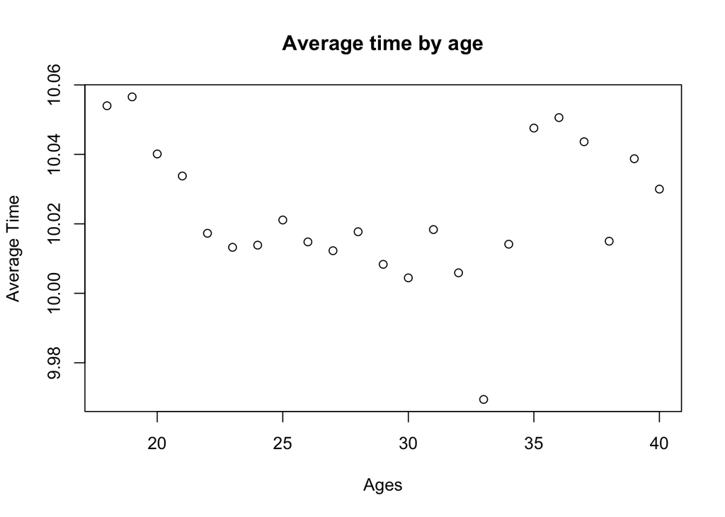

```r
plot(x = as.numeric(names(time.avg.by.age)),
     y = time.avg.by.age,
     xlab = "Ages",
     ylab = "Average Time",
     main = "Average time by age")
```

Answer: The average time for each age tends to steadily decrease until at around 32, they peak (or valley, depending on how you want to view it) at 33 on average when there was an unusually dramatic increase in speed, and then they regress slightly until 35, when they dramatically fall off.

- **5c.** As we did in Lab (2.2, Question 3a), Ddfine a character vector `sprint.years` to contain the last 4 characters of an entry of `sprint.dates`. This contains the years in which each time in the `sprint.dat` data frame was recorded. Also, define `sprint.times` to be the `Time` column of the `sprint.dat` data frame. Plot `sprint.times` versus `sprint.years`, using empty black circles. Label the x-axis “Year” and the y-axis “Time (seconds)”. Title the plot “Fastest men’s 100m sprint times”. Overlaid on top, plot the times versus years for Jamaican atheletes only, using small filled green circles. Use a legend to differentiate between the empty black circles (overall times) and small filled green circles (Jamaican times).

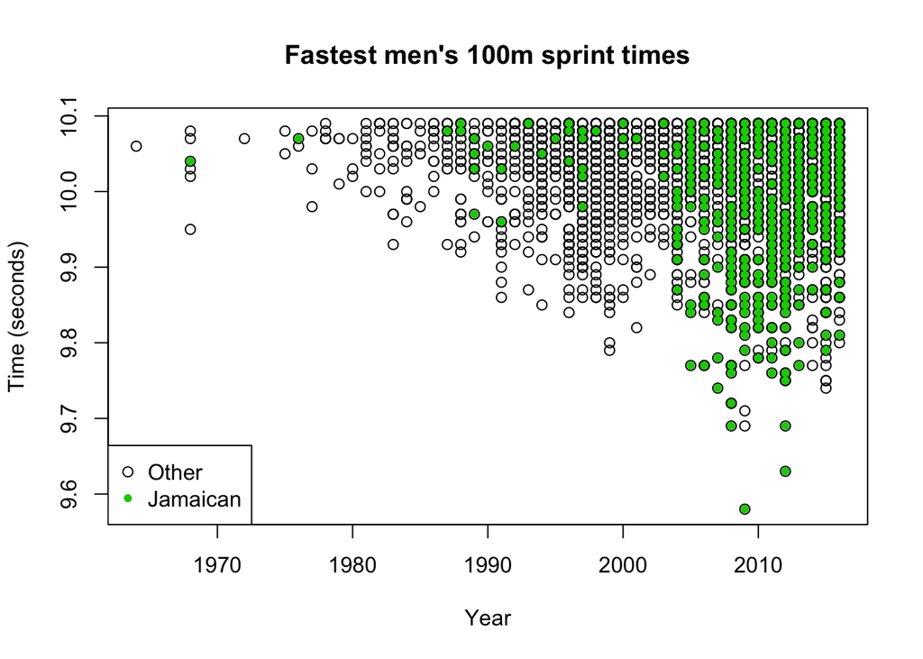

```r
#Rest defined by above code chunk.
sprint.times <- sprint.dat$Time

plot(sprint.years, sprint.times,
     pch = 1, col = 1,
     xlab = "Year", ylab = "Time (seconds)",
     main = "Fastest men's 100m sprint times")
sprint.years.jam <- sprint.years[sprint.dat$Country == "JAM"]
sprint.times.jam <- sprint.times[sprint.dat$Country == "JAM"]
points(sprint.years.jam, sprint.times.jam,
       pch = 20, col = 3)

legend("bottomleft",
       legend = c("Other", "Jamaican"),
       pch = c(1, 20),
       col = c(1, 3))
```

- **5d.** Starting with your solution code from the last question, modify it so that, instead of the Jamaican times as small filled green circles, your plot shows the US times as small filled red circles. Modify the legend appropriately too. Comment on any differences you see between the resulting plot and the one from the last question.

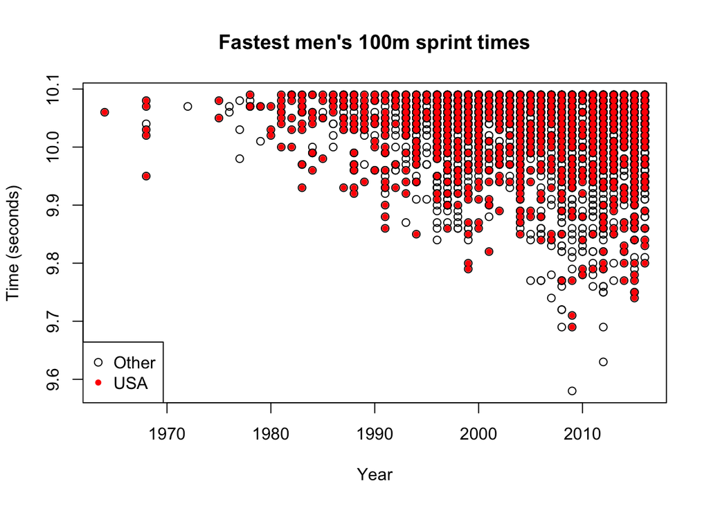

```r
plot(sprint.years, sprint.times,
     pch = 1, col = 1,
     xlab = "Year", ylab = "Time (seconds)",
     main = "Fastest men's 100m sprint times")
sprint.years.usa <- sprint.years[sprint.dat$Country == "USA"]
sprint.times.usa <- sprint.times[sprint.dat$Country == "USA"]
points(sprint.years.usa, sprint.times.usa,
       pch = 20, col = 2)

legend("bottomleft",
       legend = c("Other", "USA"),
       pch = c(1, 20),
       col = c(1, 2))
```

Answer: The USA times tended to be slower, and were more spread out over the years, but there were simply more of them, while the Jamaican times were among the absolute best, and were concentrated past the second half of the 2000’s.

# Maungawhau volcano and heatmaps

- **6a.** The `volcano` object in R is a matrix of dimension 87 x 61. It is a digitized version of a topographic map of the Maungawhau volcano in Auckland, New Zealand. Plot a heatmap of the volcano, with 25 colors from the terrain color palette.

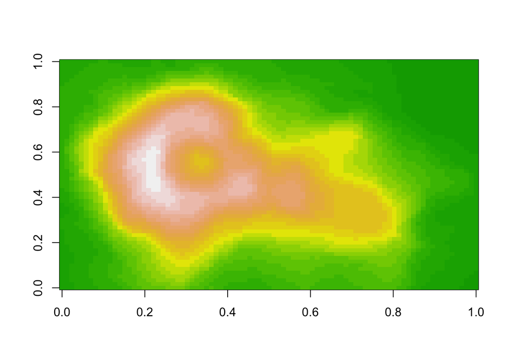

```r
image(volcano, col = terrain.colors(25))
```

- **6b.** Each row of `volcano` corresponds to a grid line running east to west. Each column of `volcano` corresponds to a grid line running south to north. Define a matrix `volcano.rev` by reversing the order of the rows, as well as the order of the columns, of `volcano`. Therefore, each row `volcano.rev` should now correspond to a grid line running west to east, and each column of `volcano.rev` a grid line running north to south.

```r
volcano.rev <- matrix(rev(volcano), nrow =  87)
# Should I have done it with multiple calls to apply? Those calls didnt' seem
# to work for me, so I reverted to this somewhat jenky way of doing it.
#volcano.rev.apply <- apply(volcano, 2, rev)
#volcano.rev.apply <- apply(volcano.rev.apply, 1, rev)
```

- **6c.** If we printed out the matrix `volcano.rev` to the console, then the elements would follow proper geographic order: left to right means west to east, and top to bottom means north to south. Now, produce a heatmap of the volcano that follows the same geographic order. Hint: recall that the `image()` function rotates a matrix 90 degrees counterclockwise before displaying it; and recall the function `clockwise90()` from the lecture, which you can copy and paste into your code here. Label the x-axis “West –> East”, and the y-axis “South –> North”. Title the plot “Heatmap of Maungawhau volcano”.

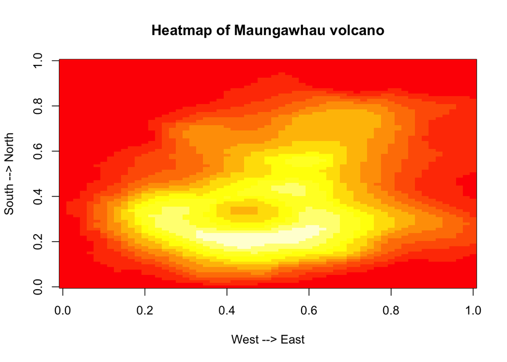

```r
# Taken from 36-350 course notes on a lecture given by Kevin Lin
clockwise90 = function(a) { t(a[nrow(a):1,]) }

image(clockwise90(volcano.rev),
      xlab = "West --> East",
      ylab = "South --> North",
      main = "Heatmap of Maungawhau volcano")
```

```r
#image(clockwise90(volcano.rev.apply))
```

- **6d.** Reproduce the previous plot, and now draw contour lines on top of the heatmap.

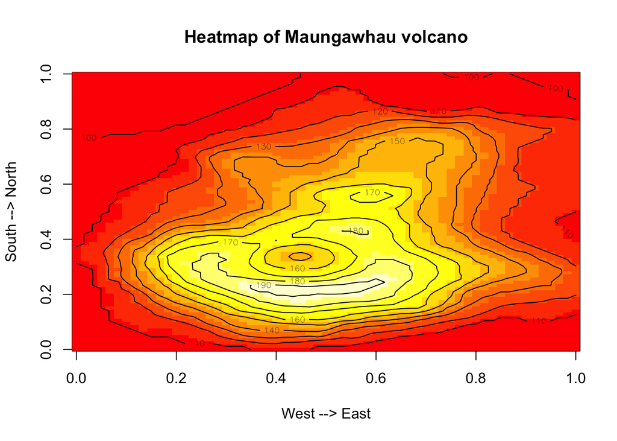

```r
image(clockwise90(volcano.rev),
      xlab = "West --> East",
      ylab = "South --> North",
      main = "Heatmap of Maungawhau volcano")

contour(clockwise90(volcano.rev), add = TRUE)
```

- **6e.** The function `filled.contour()` provides an alternative way to create a heatmap with contour lines on top. It uses the same orientation as `image()` when plotting a matrix. Use `filled.contour()` to plot a heatmap of the volcano, with (light) contour lines automatically included. Make sure the orientation of the plot matches proper geographic orientation, as in the previous question. Use a color scale of your choosing, and label the axes and title the plot appropriately. It will help to consult the documentation for `filled.contour()`.

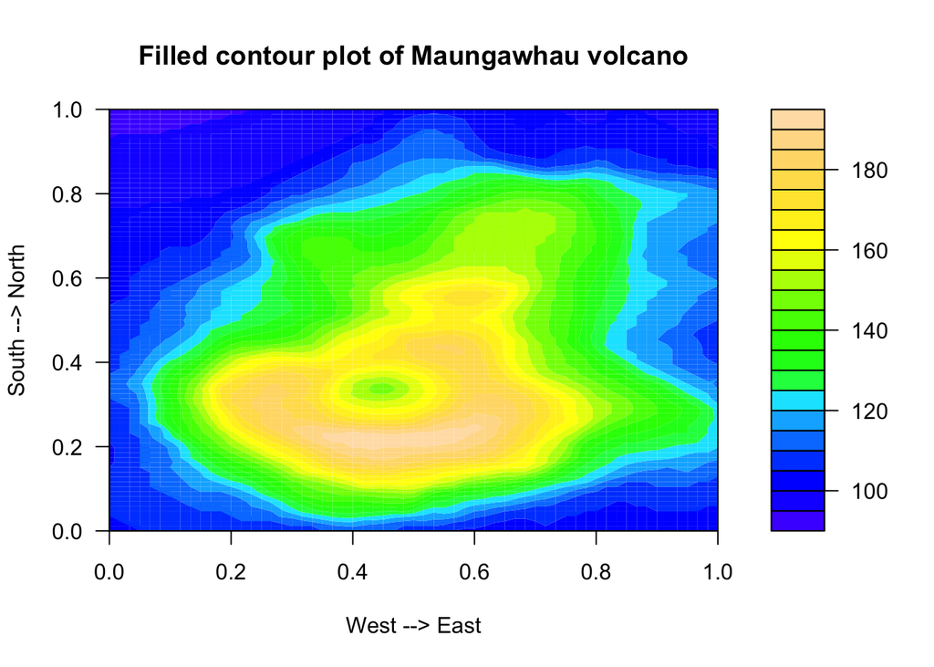

```r
filled.contour(clockwise90(volcano.rev),
               main = "Filled contour plot of Maungawhau volcano",
               xlab = "West --> East",
               ylab = "South --> North",
               color.palette = topo.colors)
```